# Time series Final Assignment

Krithik Vasan Baskar

2024-06-15

# INTRODUCTION

In the contemporary landscape of data-driven decision-making, accurate forecasting is paramount for effective business operations, particularly in sales and inventory management. The ability to predict future trends with precision facilitates optimized resource allocation, improved budget planning, and enhanced strategic initiatives. This report focuses on the application of ARIMA (AutoRegressive Integrated Moving Average) models to forecast weekly sales data, leveraging advanced statistical techniques to unearth patterns and predict future movements accurately.

The ARIMA model is widely recognized for its flexibility and efficacy in handling various types of time series data. By incorporating lags of the differenced series in autoregressive (AR) and moving average (MA) components, ARIMA models adeptly capture the temporal dependencies and random fluctuations in time series data. This report systematically explores different configurations of the ARIMA model to determine the most suitable model based on the dataset characteristics.

# METHODOLOGY

The analysis began with a preliminary examination of the data to identify trends, seasonal patterns, and potential transformations required to stabilize the variance and mean. Subsequent steps involved:

- **Model Identification**: Using plots of the data and autocorrelation function (ACF)/partial autocorrelation function (PACF) analysis to identify potential ARIMA models.
- **Parameter Estimation**: Fitting various ARIMA models to the data and refining them based on their coefficient significance and the Akaike Information Criterion (AIC), Bayesian Information Criterion (BIC), and error metrics.
- **Diagnostic Checks**: Validating the adequacy of the model fit by examining the residuals for any autocorrelation and ensuring no patterns were missed.
- **Forecasting**: Utilizing the selected ARIMA model to forecast future sales and evaluating its predictive accuracy through established error metrics such as Mean Absolute Error (MAE) and Root Mean Squared Error (RMSE).

```r
library(TSA)
library(dplyr)
library(readr)
library(tseries)
library(lmtest)
library(forecast)
library(ggplot2)
library(lubridate)
```

## Utilty functions

#### UNIT ROOT TESTS

1. **Augmented Dickey-Fuller Test (ADF)** :  
   $H_0$: It is a non stationary series  
   $H_A$: It is a stationary series We will have to reject the null hypothesis to conclude the series is stationary.
2. **Phillips-Perron Test (PP)**:  
   $H_0$: It is a non stationary series  
   $H_A$: It is a stationary series We will have to reject the null hypothesis to conclude the series is stationary.
3. **Kwiatkowski-Phillips-Schmidt-Shin (KPSS) Test**:  
   $H_0$: It is a stationary series  
   $H_A$: It is a non stationary series  
   We will have to fail to reject the null hypothesis to conclude the series is stationary.

**unit.root.test** - A Common function to run and return all the unit root test result (ADF, PP and KPSS).

```r
unit.root.test <- function(t.s){
  suppressWarnings({
  cat("Unit Root Test Results \n")
  cat("\n")
  cat(rep("-", 37), "\n")

  # Augmented Dickey-Fuller test
  adf.test.result <- adf.test(t.s)
  print(adf.test.result)
  cat("\n")
  cat(rep("-", 37), "\n")
  cat("\n")

  # Phillips-Perron test
  pp.test.result <- pp.test(t.s)
  print(pp.test.result)
  cat("\n")
  cat(rep("-", 37), "\n")
  cat("\n")

  #Kwiatkowski-Phillips-Schmidt-Shin test
  kpss.test.result <- kpss.test(t.s)
  print(kpss.test.result)
  cat("\n")
  cat(rep("-", 37), "\n")
  })
}
```

**sort.score** - A function that can sort AIC and BIC scores.

```r
sort.score <- function(x, score = c("bic", "aic")) {
  order_by <- switch(match.arg(score),
                     bic = "BIC",
                     aic = "AIC",
                     stop("score must be 'aic' or 'bic'", call. = FALSE))
  x[order(x[[order_by]]), ]
}
```

## Reading the dataset.

```r
setwd("D:\\Sem 3\\Time Series\\assignment 3")
data <- read.csv("walmart/train.csv")
```

```r
head(data)
```

```
##   Store Dept       Date Weekly_Sales IsHoliday
## 1     1    1 2010-02-05     24924.50     FALSE
## 2     1    1 2010-02-12     46039.49      TRUE
## 3     1    1 2010-02-19     41595.55     FALSE
## 4     1    1 2010-02-26     19403.54     FALSE
## 5     1    1 2010-03-05     21827.90     FALSE
## 6     1    1 2010-03-12     21043.39     FALSE
```

```r
data$Date <- as.Date(data$Date)
summary(data)
```

```
##      Store           Dept            Date             Weekly_Sales
##  Min.   : 1.0   Min.   : 1.00   Min.   :2010-02-05   Min.   : -4989
##  1st Qu.:11.0   1st Qu.:18.00   1st Qu.:2010-10-08   1st Qu.:  2080
##  Median :22.0   Median :37.00   Median :2011-06-17   Median :  7612
##  Mean   :22.2   Mean   :44.26   Mean   :2011-06-18   Mean   : 15981
##  3rd Qu.:33.0   3rd Qu.:74.00   3rd Qu.:2012-02-24   3rd Qu.: 20206
##  Max.   :45.0   Max.   :99.00   Max.   :2012-10-26   Max.   :693099
##  IsHoliday
##  Mode :logical
##  FALSE:391909
##  TRUE :29661
##
##
##
```

```r
sum(data$Weekly_Sales<0)
```

```
## [1] 1285
```

```r
data <- data[data$Weekly_Sales>0,]
data <- data[order(data$Date), ]
summary(data)
```

```
##      Store           Dept            Date             Weekly_Sales
##  Min.   : 1.0   Min.   : 1.00   Min.   :2010-02-05   Min.   :     0
##  1st Qu.:11.0   1st Qu.:18.00   1st Qu.:2010-10-08   1st Qu.:  2120
##  Median :22.0   Median :37.00   Median :2011-06-17   Median :  7662
##  Mean   :22.2   Mean   :44.24   Mean   :2011-06-18   Mean   : 16033
##  3rd Qu.:33.0   3rd Qu.:74.00   3rd Qu.:2012-02-24   3rd Qu.: 20271
##  Max.   :45.0   Max.   :99.00   Max.   :2012-10-26   Max.   :693099
##  IsHoliday
##  Mode :logical
##  FALSE:390652
##  TRUE :29560
##
##
##
```

### Summary Statistics

The dataset consists of weekly sales data across multiple stores and departments over a period. Below are the key summary statistics for each variable:

- **Store**:
  - Range: 1 to 45
  - Median: 22
  - Mean: 22.2
  - The data covers 45 different stores, with the store numbers evenly distributed.
- **Dept**:
  - Range: 1 to 99
  - Median: 37
  - Mean: 44.24
  - The dataset includes sales data from various departments, with department numbers spanning from 1 to 99.
- **Date**:
  - Range: February 5, 2010, to October 26, 2012
  - Median: June 17, 2011
  - Mean: June 18, 2011
  - The dataset covers weekly sales over approximately 2 years and 8 months.
- **Weekly_Sales**:
  - Range: 0 to 693,099
  - Median: 7,662
  - Mean: 16,033
  - The distribution of weekly sales is highly skewed, with a significant range from minimal sales to a maximum of 693,099. The median weekly sales are 7,662, indicating that half of the sales values are below this amount.
- **IsHoliday**:
  - The dataset includes 390,652 non-holiday weeks and 29,560 holiday weeks.
  - The majority of the data points represent non-holiday weeks, with only a small fraction corresponding to holiday weeks.

These summary statistics provide a comprehensive overview of the distribution and characteristics of the dataset variables.

## Converting the data into time series data

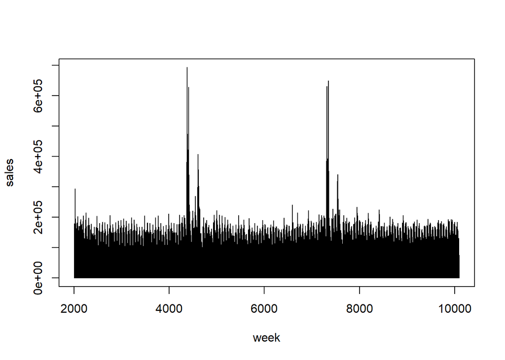

```
## [1] "ts"
```

```r
ts_data <- ts(data$Weekly_Sales, start = c(2010, 8), frequency = 52)
class(ts_data)
plot(ts_data, xlab = "week", ylab = "sales")
```

### Analysis of Time Series Plot

- **Trend**:
  - The plot of the weekly sales time series shows a relatively stable trend over the observed period. There are no significant long-term upward or downward trends visible in the data, suggesting that the overall level of sales remains fairly consistent.
- **Seasonality**:
  - The time series exhibits clear seasonal patterns. There are noticeable peaks at regular intervals, which likely correspond to seasonal events or holidays. These peaks indicate periods of increased sales, likely driven by holiday shopping or promotional activities.
- **Change in Variance**:
  - The variance in the weekly sales data appears to be relatively stable for most of the series. However, during the peak periods, there is a noticeable increase in variance, indicating higher fluctuations in sales during these times. This suggests that sales are more volatile during holiday seasons or special promotions.
- **Behavior**:
  - As we could see a clear seasonal pattern we are unable to come to a conclusion about the behavior of the series.
- **Change Point**:
  - There are a few prominent change points in the series where the sales values exhibit sharp increases. These change points correspond to significant spikes in sales, likely driven by major holidays or promotional events. These change points are critical for understanding the impact of such events on sales and for forecasting future sales patterns during similar periods.

Though we could do some analysis, its all a vague assumptions and it is very hard to do analysis or some prediction we are going to convert it into a weekly average sale analysis.

```r
weekly_avg_sales <- data %>%
  group_by(Date) %>%
  summarize(
    avg_weekly_sales = mean(Weekly_Sales),
    is_Holiday = first(IsHoliday)
  ) %>%
  ungroup()
```

```r
ts_weekly_avg_sales <- ts(weekly_avg_sales$avg_weekly_sales, start = c(2010, 8), frequency = 52)
class(ts_weekly_avg_sales)
```

```
## [1] "ts"
```

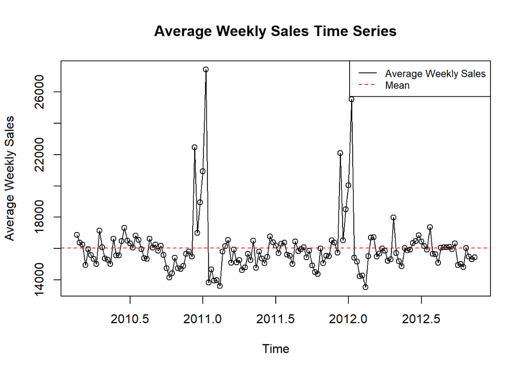

```r
mean_sales <- mean(ts_weekly_avg_sales)
plot(ts_weekly_avg_sales, type = "o", main = "Average Weekly Sales Time Series", xlab = "Time", ylab = "Average Weekly Sales", lwd = 1)
abline(h = mean_sales, col = "red", lty = 2)  # Add a horizontal line for the mean
legend("topright", legend = c("Average Weekly Sales", "Mean"), lty = c(1, 2), col = c("black", "red"), cex = 0.8)
```

### Analysis of Average Weekly Sales Time Series

- **Trend**:
  - The plot of the average weekly sales time series shows no significant long-term trend, suggesting that the overall level of sales remains relatively stable throughout the observed period.
- **Seasonality**:
  - The time series exhibits no clear seasonal behavior. But we could see 2 significant peaks. These peaks are likely associated with major holidays or promotional events, reflecting increased consumer spending during these times. But for the analysis we are going to consider there is no seasonal behavior.
- **Change in Variance**:
  - The variance in the average weekly sales data appears to be fairly consistent throughout the period, except during the peak seasons where variance increases significantly. This indicates that sales are more volatile during holiday seasons or special promotional periods.
- **Behavior**:
  - The behavior of the time series suggests a combination of moving average and autoregressive characteristics. The regular patterns and peaks indicate a moving average behavior, while the fluctuations around the mean suggest some level of autoregressive influence. This mixed behavior is typical in time series data with seasonal effects.
- **Change Points**:
  - There are distinct change points in the series, marked by significant spikes in average weekly sales. These change points correspond to the holiday seasons, where sales sharply increase. Identifying these change points is crucial for understanding the impact of seasonal events on sales and for improving forecasting accuracy during similar periods.

Overall, the average weekly sales time series shows a stable trend with clear seasonal peaks and increased variance during high sales periods. The series exhibits both moving average and auto-regressive behaviors, with significant change points corresponding to holiday seasons. This analysis provides valuable insights for understanding sales patterns and for planning future sales strategies.

### LAGS

Let us use zlag() function to see if there is any dependency of one week sales with its next week.

#### First Lag :

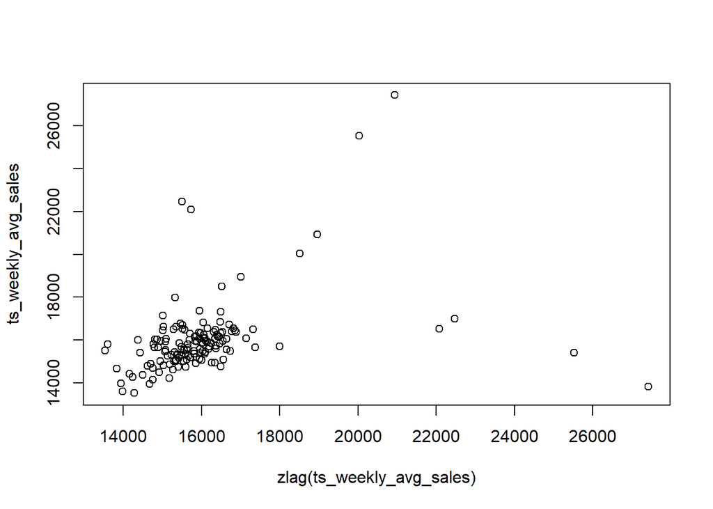

```r
plot(y= ts_weekly_avg_sales, x = zlag(ts_weekly_avg_sales))
```

```r
y = ts_weekly_avg_sales

x = zlag(ts_weekly_avg_sales)

index = 2:length(x)

cat("Correlation of the first-lag : ",cor(y[index], x[index]))
```

```
## Correlation of the first-lag :  0.3275855
```

**Interpretation**: - This moderate positive correlation indicates that there is a reasonable degree of autocorrelation in the time series. Specifically, it suggests that the sales in one week are moderately correlated with the sales in the following week. - This level of correlation implies some degree of predictability in weekly sales based on the previous week’s sales, but it is not strong enough to rely solely on past sales for forecasting future sales.

# EVALUVATION OF STATIONARITY BEHAVIOUR OF THE DATA

## ACF and PACF plot

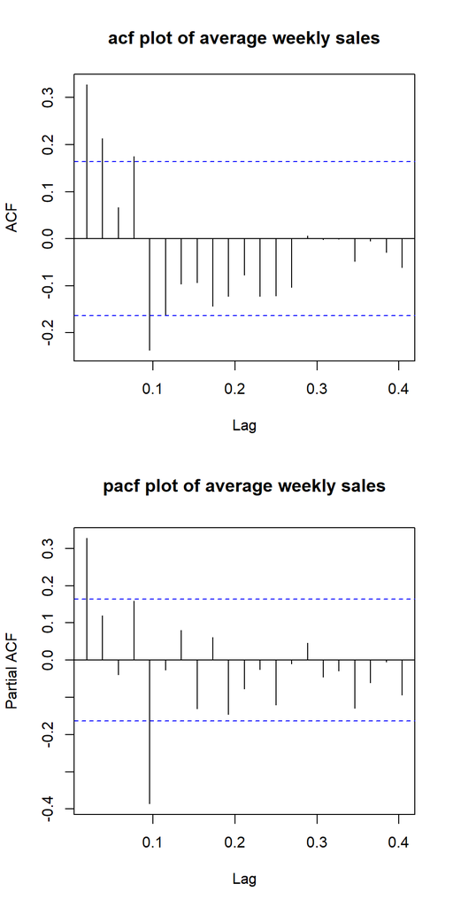

```r
par(mfrow = c(2,1))
acf(ts_weekly_avg_sales, main = 'acf plot of average weekly sales')
pacf(ts_weekly_avg_sales, main = 'pacf plot of average weekly sales')
```

### Interpretation

- **Stationarity**:
  - Both the ACF and PACF plots indicate that the average weekly sales time series is stationary. The rapid decay in the ACF plot and the significant spike at the first lag in the PACF plot are consistent with the characteristics of a stationary time series.
  - The stationarity of the series implies that the statistical properties such as mean and variance are constant over time, making the series suitable for modeling using ARIMA or similar time series models.

This analysis confirms that the average weekly sales time series is stationary, providing a solid foundation for further time series modeling and forecasting.

#### Unit testing for confirmation :

```r
unit.root.test(ts_weekly_avg_sales)
```

```
## Unit Root Test Results
##
## - - - - - - - - - - - - - - - - - - - - - - - - - - - - - - - - - - - - -
##
##  Augmented Dickey-Fuller Test
##
## data:  t.s
## Dickey-Fuller = -5.3367, Lag order = 5, p-value = 0.01
## alternative hypothesis: stationary
##
##
## - - - - - - - - - - - - - - - - - - - - - - - - - - - - - - - - - - - - -
##
##
##  Phillips-Perron Unit Root Test
##
## data:  t.s
## Dickey-Fuller Z(alpha) = -104.84, Truncation lag parameter = 4, p-value
## = 0.01
## alternative hypothesis: stationary
##
##
## - - - - - - - - - - - - - - - - - - - - - - - - - - - - - - - - - - - - -
##
##
##  KPSS Test for Level Stationarity
##
## data:  t.s
## KPSS Level = 0.033142, Truncation lag parameter = 4, p-value = 0.1
##
##
## - - - - - - - - - - - - - - - - - - - - - - - - - - - - - - - - - - - - -
```

The results from various unit root tests provide strong evidence supporting the stationarity of the average weekly sales time series. Below are the key findings from each test:

- **Augmented Dickey-Fuller (ADF) Test**:
  - The test statistic is -5.3367, with a p-value of 0.01.
  - The null hypothesis of the ADF test is that the series has a unit root (non-stationary). Given the low p-value, we reject the null hypothesis in favor of the alternative hypothesis, indicating that the series is stationary.
- **Phillips-Perron (PP) Test**:
  - The test statistic is -104.84, with a p-value of 0.01.
  - Similar to the ADF test, the null hypothesis of the PP test is the presence of a unit root. The low p-value leads us to reject the null hypothesis, supporting the stationarity of the series.
- **KPSS Test for Level Stationarity**:
  - The test statistic is 0.033142, with a p-value of 0.1.
  - The null hypothesis of the KPSS test is that the series is level stationary. With a high p-value, we fail to reject the null hypothesis, providing further evidence that the series is stationary.

The unit root tests, including the Augmented Dickey-Fuller, Phillips-Perron, and KPSS tests, all indicate that the average weekly sales time series is stationary. These results corroborate the findings from the ACF and PACF plots, which also suggested stationarity. The combination of visual and statistical evidence provides a robust confirmation of the stationarity of the series, making it well-suited for further time series analysis and modeling.

## NORMALITY TEST

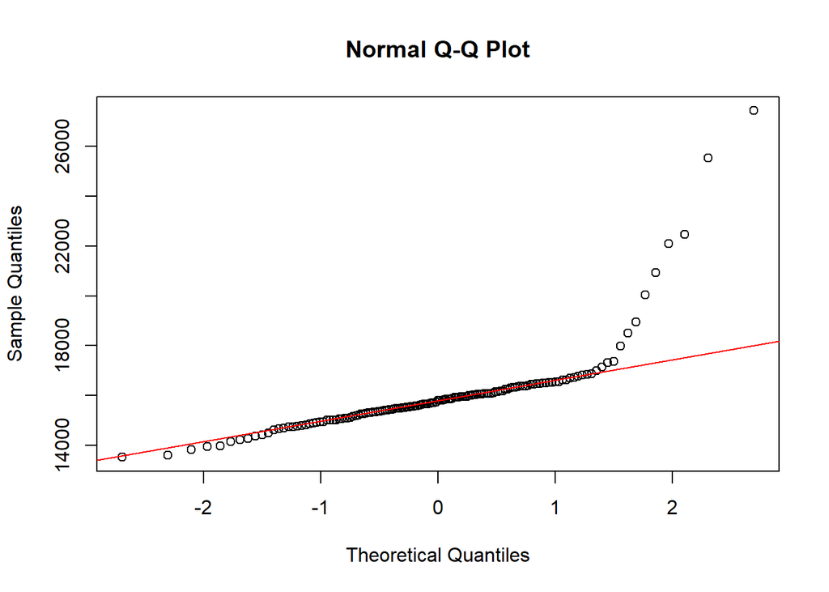

```r
qqnorm(ts_weekly_avg_sales)
qqline(ts_weekly_avg_sales, col = 'red')
```

The average weekly sales data is not normally distributed. The QQ plot shows significant deviations from the reference line, particularly in the tails, indicating the presence of extreme values or outliers. While the central portion of the data follows a normal distribution reasonably well, the substantial deviations in the tails suggest that the data does not adhere to a normal distribution overall.

```r
shapiro.test(ts_weekly_avg_sales)
```

```
##
##  Shapiro-Wilk normality test
##
## data:  ts_weekly_avg_sales
## W = 0.64666, p-value < 2.2e-16
```

The Shapiro-Wilk test results, with a W statistic of 0.64666 and a p-value less than 2.2e-16, indicate that the average weekly sales data is **not normally distributed**. This further supports the findings from the QQ plot, confirming that the dataset deviates from normality and has characteristics such as heavy tails or outliers.

## TRANSFORMATION

```r
min(ts_weekly_avg_sales)
```

```
## [1] 13535.55
```

As we could see the minimum value of the time series data is 13535.55, which is a positive data. Therefore we can proceed with the Box cox transformation.

```r
Box.cox.weekly_sales <- BoxCox.ar(ts_weekly_avg_sales)
```

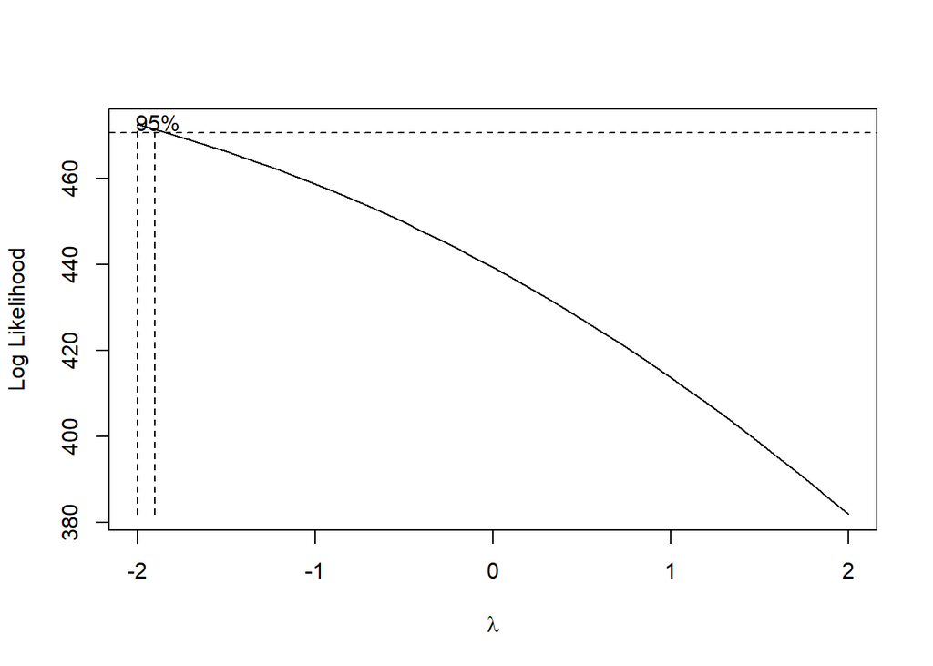

```r
# The value of the first and the last line in the Box Cox plot.
Box.cox.weekly_sales$ci
```

```
## [1] -2.0 -1.9
```

```r
lambda_value <- Box.cox.weekly_sales$lambda[which(max(Box.cox.weekly_sales$loglike) == Box.cox.weekly_sales$loglike)]
lambda_value
```

```
## [1] -2
```

- The optimal lambda value for the Box-Cox transformation was found to be -2, with a 95% confidence interval ranging from -2.0 to -1.9.
- Applying the transformation with λ = -2 stabilizes the variance and helps in normalizing the data.

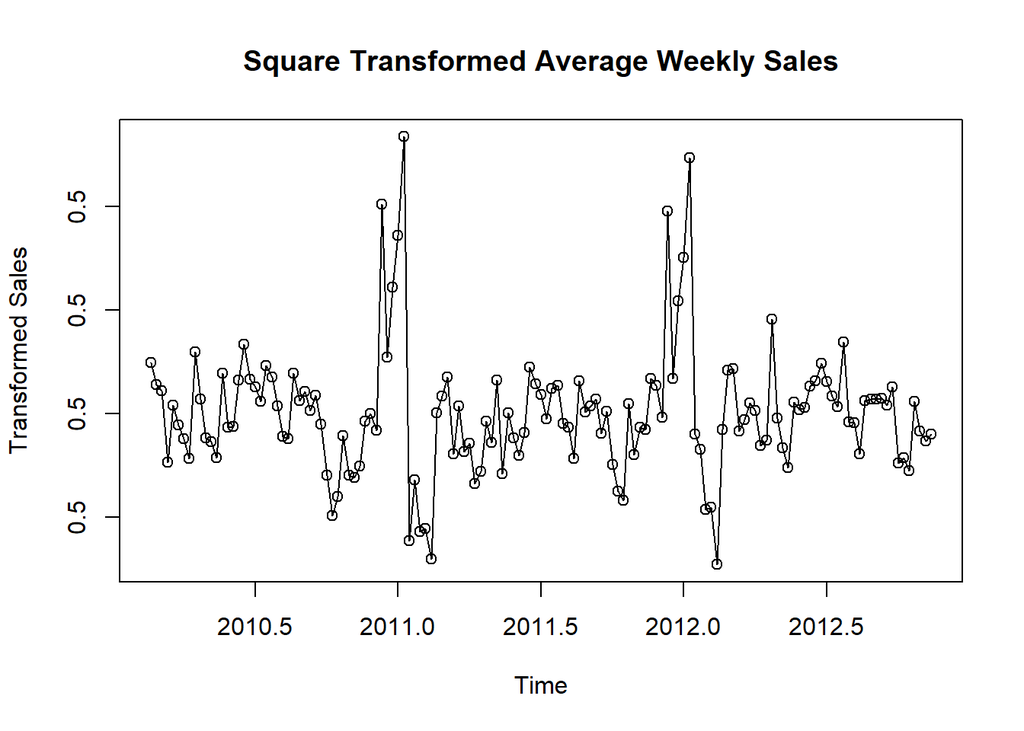

```r
# Perform lambda transformation
ts_weekly_avg_sales_transformed <- ((ts_weekly_avg_sales^lambda_value) - 1) / lambda_value

# Plot the transformed series
plot(ts_weekly_avg_sales_transformed, type = "o", main = "Square Transformed Average Weekly Sales", xlab = "Time", ylab = "Transformed Sales", lwd = 1)
```

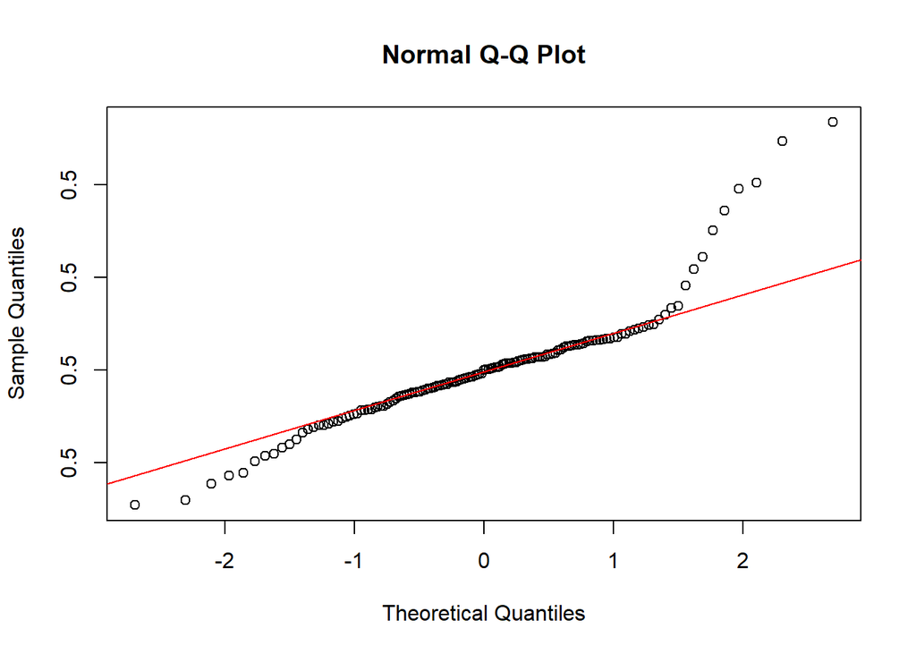

```r
qqnorm(ts_weekly_avg_sales_transformed)
qqline(ts_weekly_avg_sales_transformed, col = 'red')
```

```r
shapiro.test(ts_weekly_avg_sales_transformed)
```

```
##
##  Shapiro-Wilk normality test
##
## data:  ts_weekly_avg_sales_transformed
## W = 0.88757, p-value = 5.263e-09
```

Given the p-value is significantly less than 0.05, we reject the null hypothesis.

The Shapiro-Wilk test results, with a W statistic of 0.88757 and a p-value of 5.263e-09, indicate that even after the Box-Cox transformation with λ = -2, the average weekly sales data is not normally distributed. Although the transformation aimed to stabilize variance and normalize the data, it appears that significant deviations from normality remain.

But we are going to proceed with this transformed series.

# MODEL SPECIFICATION

## FROM THE ACF AND PACF PLOT

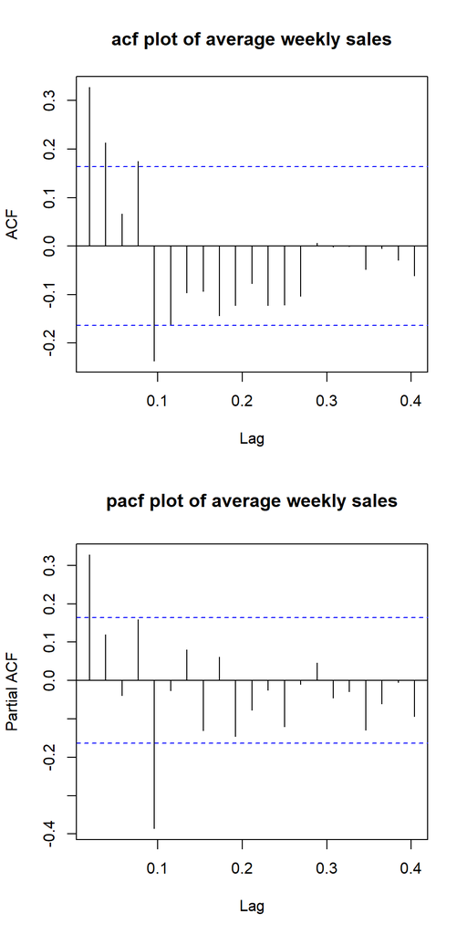

```r
par(mfrow = c(2,1))
acf(ts_weekly_avg_sales, main = 'acf plot of average weekly sales')
pacf(ts_weekly_avg_sales, main = 'pacf plot of average weekly sales')
```

### Model Specification Suggestions

From the ACF and PACF plots we finalize the following ARIMA models for further analysis :

- **ARIMA(1,0,1)**
- **ARIMA(1,0,2)**
- **ARIMA(1,0,3)**
- **ARIMA(1,0,4)**
- **ARIMA(2,0,1)**
- **ARIMA(2,0,2)**
- **ARIMA(2,0,3)**
- **ARIMA(2,0,4)**

## FROM THE EXTENDED ACF PLOT (EACF)

```r
eacf(ts_weekly_avg_sales_transformed, ar.max = 10, ma.max = 10)
```

```
## AR/MA
##    0 1 2 3 4 5 6 7 8 9 10
## 0  x x o o x x o o o o o
## 1  x x x o x o o o o o o
## 2  x o o o x o o o o o o
## 3  x o o x x o o o o o o
## 4  o x o x x o o o o o o
## 5  o x x o x o o o o o o
## 6  o o o o x o o o o o o
## 7  x x o o x x o o o o o
## 8  o x x o x x o o o o o
## 9  o x x x x x o o o o o
## 10 x o o x o o o o x o o
```

- **ARIMA(1,0,5)**
- **ARIMA(2,0,5)**
- **ARIMA(1,0,6)**
- **ARIMA(2,0,6)**

## FROM THE BAYESIAN INFORMATION CRITERION (BIC) MODEL

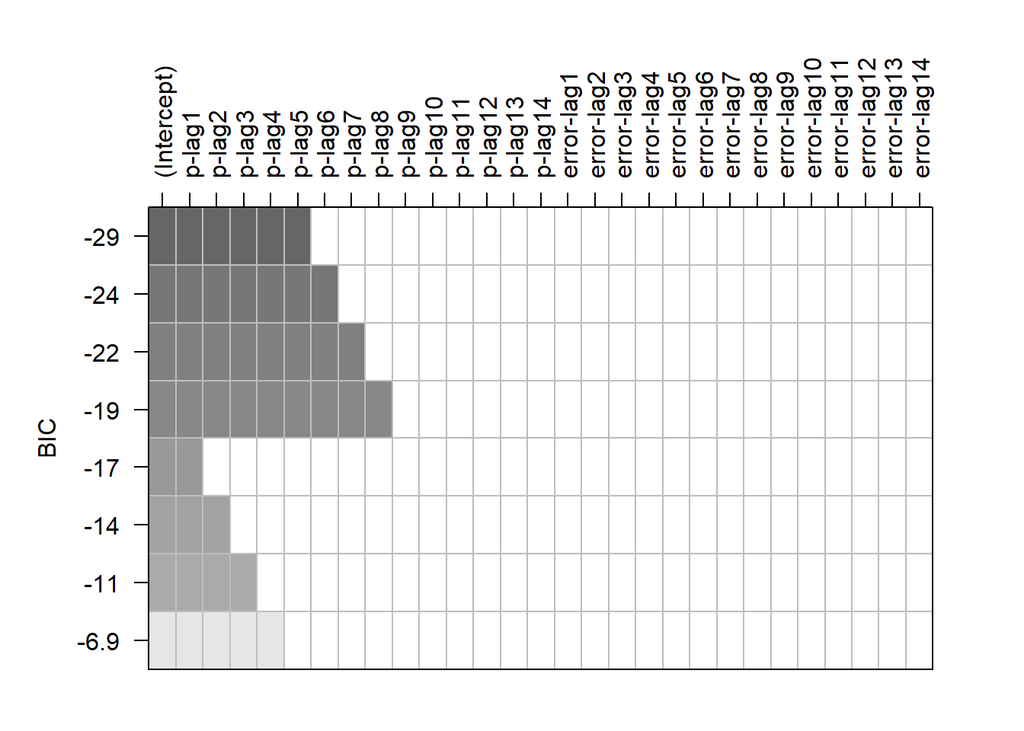

```r
BIC_model_weekly_sales = armasubsets(y= ts_weekly_avg_sales_transformed, nar=14, nma=14, y.name='p', ar.method='ols')
plot(BIC_model_weekly_sales)
```

**Final analysis** :

By taking everything in the consideration from the all the plot(ACF-PACF, EACF, and BIC), we can observe the following possible ARIMA models for the model fitting:

- **ARIMA(1,0,0)**
- **ARIMA(1,0,1)**
- **ARIMA(1,0,2)**
- **ARIMA(1,0,3)**
- **ARIMA(1,0,4)**
- **ARIMA(1,0,5)**
- **ARIMA(1,0,6)**
- **ARIMA(2,0,0)**
- **ARIMA(2,0,1)**
- **ARIMA(2,0,2)**
- **ARIMA(2,0,3)**
- **ARIMA(2,0,4)**
- **ARIMA(2,0,5)**
- **ARIMA(2,0,6)**
- **ARIMA(3,0,0)**
- **ARIMA(4,0,0)**

# MODEL FITTING

For fitting ARIMA models to your time series data, you can apply different estimation techniques, each with unique advantages and applications. Here, we’ll explore the application of Maximum Likelihood (ML), Least Squares (LS), and a hybrid CSS-ML estimation method.

#### 1. Maximum Likelihood Estimation (ML)

- **Overview**: Maximum Likelihood Estimation is a widely used method in time series analysis for estimating the parameters of ARIMA models. It involves finding the parameter values that maximize the likelihood function, assuming the residuals are normally distributed.
- **Advantages**: ML is flexible and statistically efficient, providing estimates with good properties (like consistency and asymptotic normality) when the model is correctly specified and the sample size is large.

#### 2. Least Squares Estimation (LS)

- **Overview**: Least Squares, particularly Conditional Least Squares (CLS) for ARIMA models, involves minimizing the sum of squared differences between observed values and those predicted by the model. It’s generally applied conditionally on the initial observations.
- **Advantages**: LS is straightforward to understand and implement, and it’s particularly useful when dealing with non-stationary data where initial differencing steps are required.

#### 3. CSS-ML Estimation

- **Overview**: This approach might involve starting the estimation with Conditional Least Squares to obtain initial parameter estimates, which are then refined using the Maximum Likelihood method.
- **Advantages**: Combining CSS and ML can lead to more robust estimates, especially in cases where ML estimation alone may struggle due to non-optimal starting values or complex model structures.

## ARIMA(1,0,0)

```r
wsmodel.100.ml = Arima(ts_weekly_avg_sales_transformed,order=c(1,0,0),method='ML')
coeftest(wsmodel.100.ml)

wsmodel.100.css = Arima(ts_weekly_avg_sales_transformed,order=c(1,0,0),method='CSS')
coeftest(wsmodel.100.css)
```

```
##
## z test of coefficients:
##
##           Estimate Std. Error z value Pr(>|z|)
## ar1        0.42393        NaN     NaN      NaN
## intercept  0.50000        NaN     NaN      NaN
##
##
## z test of coefficients:
##
##           Estimate Std. Error z value Pr(>|z|)
## ar1        0.42494        NaN     NaN      NaN
## intercept  0.50000        NaN     NaN      NaN
```

As we have got nan values in all the columns we could conclude that this is not a vaiable model.

## ARIMA(1,0,1)

```r
wsmodel.101.ml = Arima(ts_weekly_avg_sales_transformed,order=c(1,0,1),method='ML')
coeftest(wsmodel.101.ml)

wsmodel.101.css = Arima(ts_weekly_avg_sales_transformed,order=c(1,0,1),method='CSS')
coeftest(wsmodel.101.css)

wsmodel.101.CSSml = Arima(ts_weekly_avg_sales_transformed,order=c(1,0,1),method='CSS-ML')
coeftest(wsmodel.101.CSSml)
```

```
##
## z test of coefficients:
##
##            Estimate Std. Error z value  Pr(>|z|)
## ar1        0.562463   0.072259  7.7840 7.029e-15 ***
## ma1       -0.166448   0.130874 -1.2718    0.2034
## intercept  0.500000        NaN     NaN       NaN
## ---
## Signif. codes:  0 '***' 0.001 '**' 0.01 '*' 0.05 '.' 0.1 ' ' 1
##
##
## z test of coefficients:
##
##             Estimate Std. Error z value Pr(>|z|)
## ar1        0.5627969  0.0061074 92.1506  < 2e-16 ***
## ma1       -0.1660582  0.0824241 -2.0147  0.04394 *
## intercept  0.5000000        NaN     NaN      NaN
## ---
## Signif. codes:  0 '***' 0.001 '**' 0.01 '*' 0.05 '.' 0.1 ' ' 1
##
##
## z test of coefficients:
##
##            Estimate Std. Error z value  Pr(>|z|)
## ar1        0.562644   0.072377  7.7738 7.614e-15 ***
## ma1       -0.166715   0.130928 -1.2733    0.2029
## intercept  0.500000        NaN     NaN       NaN
## ---
## Signif. codes:  0 '***' 0.001 '**' 0.01 '*' 0.05 '.' 0.1 ' ' 1
```

Based on the results for the ARIMA(1,0,1) model, the `ar1` coefficient is consistently estimated with high significance across all estimation methods, indicating a robust autoregressive component. However, the `ma1` coefficient varies in its significance, being statistically insignificant in two estimations and marginally significant in another. This variability suggests that the moving average component may not be necessary for capturing the dynamics of the series. The intercept remains unassessed due to missing statistical details. Given these observations, ARIMA(1,0,1) with an emphasis on the AR component is generally supported, but further scrutiny or possible model simplification by removing the `ma1` component could be warranted to enhance model parsimony and focus on the significant features of the data.

## ARIMA(1,0,2)

```r
wsmodel.102.ml = Arima(ts_weekly_avg_sales_transformed,order=c(1,0,2),method='ML')
coeftest(wsmodel.102.ml)

wsmodel.102.css = Arima(ts_weekly_avg_sales_transformed,order=c(1,0,2),method='CSS')
coeftest(wsmodel.102.css)

wsmodel.102.CSSml = Arima(ts_weekly_avg_sales_transformed,order=c(1,0,2),method='CSS-ML')
coeftest(wsmodel.102.CSSml)
```

```
##
## z test of coefficients:
##
##            Estimate Std. Error z value  Pr(>|z|)
## ar1        0.451462   0.103255  4.3723 1.229e-05 ***
## ma1       -0.067686   0.165764 -0.4083    0.6830
## ma2        0.098512   0.082266  1.1975    0.2311
## intercept  0.500000        NaN     NaN       NaN
## ---
## Signif. codes:  0 '***' 0.001 '**' 0.01 '*' 0.05 '.' 0.1 ' ' 1
##
##
## z test of coefficients:
##
##            Estimate Std. Error z value Pr(>|z|)
## ar1        0.463546   0.013831 33.5162   <2e-16 ***
## ma1       -0.080713   0.077982 -1.0350   0.3007
## ma2        0.097255   0.073859  1.3168   0.1879
## intercept  0.500000        NaN     NaN      NaN
## ---
## Signif. codes:  0 '***' 0.001 '**' 0.01 '*' 0.05 '.' 0.1 ' ' 1
##
##
## z test of coefficients:
##
##            Estimate Std. Error z value  Pr(>|z|)
## ar1        0.451818   0.104499  4.3236 1.535e-05 ***
## ma1       -0.068083   0.166864 -0.4080    0.6833
## ma2        0.098408   0.082332  1.1953    0.2320
## intercept  0.500000        NaN     NaN       NaN
## ---
## Signif. codes:  0 '***' 0.001 '**' 0.01 '*' 0.05 '.' 0.1 ' ' 1
```

The ARIMA(1,0,2) model analysis across different estimation methods highlights a consistently significant autoregressive term (`ar1`), suggesting a strong influence on the model. However, the moving average terms (`ma1` and `ma2`) lack significant contribution across all methods, with `ma1` consistently showing insignificance. This inconsistency in the moving average terms suggests that a simpler model, potentially ARIMA(1,0,0), could be more appropriate for the data, as it would reduce complexity without sacrificing model accuracy.

## ARIMA(1,0,3)

```r
wsmodel.103.ml = Arima(ts_weekly_avg_sales_transformed, order=c(1,0,3), method='ML')
coeftest(wsmodel.103.ml)

wsmodel.103.css = Arima(ts_weekly_avg_sales_transformed, order=c(1,0,3), method='CSS')
coeftest(wsmodel.103.css)

wsmodel.103.CSSml = Arima(ts_weekly_avg_sales_transformed, order=c(1,0,3), method='CSS-ML')
coeftest(wsmodel.103.CSSml)
```

```
##
## z test of coefficients:
##
##            Estimate Std. Error z value  Pr(>|z|)
## ar1       -0.709860   0.120061 -5.9125 3.370e-09 ***
## ma1        1.213914   0.136833  8.8715 < 2.2e-16 ***
## ma2        0.590426   0.115184  5.1259 2.961e-07 ***
## ma3       -0.012917   0.089195 -0.1448    0.8849
## intercept  0.500000        NaN     NaN       NaN
## ---
## Signif. codes:  0 '***' 0.001 '**' 0.01 '*' 0.05 '.' 0.1 ' ' 1
##
##
## z test of coefficients:
##
##            Estimate Std. Error z value  Pr(>|z|)
## ar1       -0.668762   0.084784 -7.8878 3.076e-15 ***
## ma1        1.173080   0.028910 40.5775 < 2.2e-16 ***
## ma2        0.571745   0.077712  7.3572 1.878e-13 ***
## ma3       -0.026035   0.071032 -0.3665     0.714
## intercept  0.500000        NaN     NaN       NaN
## ---
## Signif. codes:  0 '***' 0.001 '**' 0.01 '*' 0.05 '.' 0.1 ' ' 1
##
##
## z test of coefficients:
##
##            Estimate Std. Error z value  Pr(>|z|)
## ar1       -0.709854   0.120420 -5.8948 3.751e-09 ***
## ma1        1.213987   0.136462  8.8962 < 2.2e-16 ***
## ma2        0.590525   0.114175  5.1721 2.315e-07 ***
## ma3       -0.012871   0.089033 -0.1446    0.8851
## intercept  0.500000        NaN     NaN       NaN
## ---
## Signif. codes:  0 '***' 0.001 '**' 0.01 '*' 0.05 '.' 0.1 ' ' 1
```

The ARIMA(1,0,3) model analysis using different estimation methods consistently shows a significant negative autoregressive term (`ar1`) and two significantly positive moving average terms (`ma1` and `ma2`). The third moving average term (`ma3`), however, is not significant in any of the models, suggesting it might be superfluous. The consistently significant `ar1`, `ma1`, and `ma2` across all methods indicate these components are vital for the model, reflecting substantial autoregressive and moving average effects in the data. The lack of significance in the `ma3` and the absence of an assessable intercept suggest a possible simplification by removing the `ma3` term could improve model parsimony without losing predictive power.

## ARIMA(1,0,4)

```r
wsmodel.104.ml = Arima(ts_weekly_avg_sales_transformed, order=c(1,0,4), method='ML')
coeftest(wsmodel.104.ml)

wsmodel.104.css = Arima(ts_weekly_avg_sales_transformed, order=c(1,0,4), method='CSS')
coeftest(wsmodel.104.css)

wsmodel.104.CSSml = Arima(ts_weekly_avg_sales_transformed, order=c(1,0,4), method='CSS-ML')
coeftest(wsmodel.104.CSSml)
```

```
##
## z test of coefficients:
##
##            Estimate Std. Error z value  Pr(>|z|)
## ar1       -0.114434   0.136391 -0.8390 0.4014621
## ma1        0.585016   0.133178  4.3927 1.119e-05 ***
## ma2        0.487690   0.081224  6.0043 1.922e-09 ***
## ma3        0.315645   0.083930  3.7608 0.0001694 ***
## ma4        0.475056   0.075200  6.3173 2.663e-10 ***
## intercept  0.500000        NaN     NaN       NaN
## ---
## Signif. codes:  0 '***' 0.001 '**' 0.01 '*' 0.05 '.' 0.1 ' ' 1
##
##
## z test of coefficients:
##
##            Estimate Std. Error z value  Pr(>|z|)
## ar1       -0.098059   0.111552 -0.8790    0.3794
## ma1        0.574954   0.098549  5.8342 5.404e-09 ***
## ma2        0.493152   0.087066  5.6641 1.478e-08 ***
## ma3        0.313315   0.058342  5.3703 7.859e-08 ***
## ma4        0.486891   0.069788  6.9767 3.021e-12 ***
## intercept  0.500000        NaN     NaN       NaN
## ---
## Signif. codes:  0 '***' 0.001 '**' 0.01 '*' 0.05 '.' 0.1 ' ' 1
##
##
## z test of coefficients:
##
##            Estimate Std. Error z value  Pr(>|z|)
## ar1       -0.114402   0.147398 -0.7761    0.4377
## ma1        0.584993   0.137414  4.2571 2.071e-05 ***
## ma2        0.487660   0.078607  6.2038 5.513e-10 ***
## ma3        0.315562   0.077598  4.0666 4.770e-05 ***
## ma4        0.475050   0.075784  6.2685 3.646e-10 ***
## intercept  0.500000        NaN     NaN       NaN
## ---
## Signif. codes:  0 '***' 0.001 '**' 0.01 '*' 0.05 '.' 0.1 ' ' 1
```

The ARIMA(1,0,4) model results show consistently significant moving average terms (`ma1`, `ma2`, `ma3`, and `ma4`) across all estimation methods, indicating a strong influence of past errors on the current value. Each of these coefficients is statistically significant with very low p-values, highlighting their importance in the model. In contrast, the autoregressive term (`ar1`) is not significant in any of the methods, suggesting that the previous values do not significantly influence the current value beyond the moving average components. The absence of significance for the intercept (due to missing data) and the consistently non-significant `ar1` suggest that the model’s dynamics are predominantly driven by the moving average process. This model’s complexity may be justified given the significant contribution of each moving average term, but the lack of autoregressive impact might also indicate potential overfitting or the need for a simpler MA model.

## ARIMA(1,0,5)

```r
wsmodel.105.ml = Arima(ts_weekly_avg_sales_transformed, order=c(1,0,5), method='ML')
coeftest(wsmodel.105.ml)

wsmodel.105.css = Arima(ts_weekly_avg_sales_transformed, order=c(1,0,5), method='CSS')
coeftest(wsmodel.105.css)

wsmodel.105.CSSml = Arima(ts_weekly_avg_sales_transformed, order=c(1,0,5), method='CSS-ML')
coeftest(wsmodel.105.CSSml)
```

```
##
## z test of coefficients:
##
##            Estimate Std. Error z value  Pr(>|z|)
## ar1        0.779779   0.023559 33.0986 < 2.2e-16 ***
## ma1       -0.437491   0.079451 -5.5064 3.662e-08 ***
## ma2       -0.021027   0.088482 -0.2376   0.81216
## ma3       -0.167225   0.090950 -1.8386   0.06597 .
## ma4        0.148551   0.066070  2.2484   0.02455 *
## ma5       -0.522807   0.067991 -7.6893 1.479e-14 ***
## intercept  0.500000        NaN     NaN       NaN
## ---
## Signif. codes:  0 '***' 0.001 '**' 0.01 '*' 0.05 '.' 0.1 ' ' 1
##
##
## z test of coefficients:
##
##            Estimate Std. Error z value  Pr(>|z|)
## ar1        0.738929   0.028843 25.6194 < 2.2e-16 ***
## ma1       -0.423443   0.118597 -3.5704 0.0003564 ***
## ma2       -0.033734   0.088309 -0.3820 0.7024584
## ma3       -0.191486   0.090169 -2.1236 0.0337008 *
## ma4        0.104376   0.103475  1.0087 0.3131168
## ma5       -0.591468   0.086528 -6.8356 8.167e-12 ***
## intercept  0.500000        NaN     NaN       NaN
## ---
## Signif. codes:  0 '***' 0.001 '**' 0.01 '*' 0.05 '.' 0.1 ' ' 1
##
##
## z test of coefficients:
##
##            Estimate Std. Error z value  Pr(>|z|)
## ar1        0.779800   0.023525 33.1476 < 2.2e-16 ***
## ma1       -0.437420   0.079448 -5.5057 3.677e-08 ***
## ma2       -0.021162   0.088475 -0.2392   0.81096
## ma3       -0.167094   0.090936 -1.8375   0.06614 .
## ma4        0.148497   0.066064  2.2478   0.02459 *
## ma5       -0.522811   0.067989 -7.6897 1.475e-14 ***
## intercept  0.500000        NaN     NaN       NaN
## ---
## Signif. codes:  0 '***' 0.001 '**' 0.01 '*' 0.05 '.' 0.1 ' ' 1
```

The ARIMA(1,0,5) model, examined through various estimation methods, indicates a consistently significant autoregressive term (`ar1`) and strong effects from the first and fifth moving average terms (`ma1` and `ma5`). However, the middle moving average coefficients (`ma2`, `ma3`, `ma4`) exhibit inconsistent significance, suggesting potential overfitting. Simplifying the model by focusing on consistently significant terms might improve efficiency and reduce unnecessary complexity.

## ARIMA(1,0,6)

```r
wsmodel.106.ml = Arima(ts_weekly_avg_sales_transformed, order=c(1,0,6), method='ML')
coeftest(wsmodel.106.ml)

wsmodel.106.css = Arima(ts_weekly_avg_sales_transformed, order=c(1,0,6), method='CSS')
coeftest(wsmodel.106.css)

wsmodel.106.CSSml = Arima(ts_weekly_avg_sales_transformed, order=c(1,0,6), method='CSS-ML')
coeftest(wsmodel.106.CSSml)
```

```
##
## z test of coefficients:
##
##            Estimate Std. Error z value  Pr(>|z|)
## ar1        0.743360   0.037751 19.6912 < 2.2e-16 ***
## ma1       -0.379823   0.103812 -3.6588 0.0002534 ***
## ma2       -0.016417   0.081822 -0.2006 0.8409747
## ma3       -0.179826   0.086656 -2.0752 0.0379716 *
## ma4        0.157580   0.072643  2.1692 0.0300638 *
## ma5       -0.499438   0.075278 -6.6345 3.255e-11 ***
## ma6       -0.081982   0.104560 -0.7841 0.4330022
## intercept  0.500000        NaN     NaN       NaN
## ---
## Signif. codes:  0 '***' 0.001 '**' 0.01 '*' 0.05 '.' 0.1 ' ' 1
##
##
## z test of coefficients:
##
##             Estimate Std. Error z value  Pr(>|z|)
## ar1        0.6051351  0.0082444 73.3999 < 2.2e-16 ***
## ma1       -0.2893185  0.0596292 -4.8520 1.222e-06 ***
## ma2       -0.0440285  0.0792306 -0.5557  0.578415
## ma3       -0.2200517  0.0748417 -2.9402  0.003280 **
## ma4        0.0967691  0.0762465  1.2692  0.204384
## ma5       -0.5365310  0.0714287 -7.5114 5.849e-14 ***
## ma6       -0.2059302  0.0732482 -2.8114  0.004933 **
## intercept  0.5000000        NaN     NaN       NaN
## ---
## Signif. codes:  0 '***' 0.001 '**' 0.01 '*' 0.05 '.' 0.1 ' ' 1
##
##
## z test of coefficients:
##
##            Estimate Std. Error z value  Pr(>|z|)
## ar1        0.743408   0.037502 19.8234 < 2.2e-16 ***
## ma1       -0.379843   0.103711 -3.6625 0.0002497 ***
## ma2       -0.016449   0.081838 -0.2010 0.8407060
## ma3       -0.179779   0.086652 -2.0747 0.0380119 *
## ma4        0.157560   0.072775  2.1650 0.0303868 *
## ma5       -0.499361   0.075277 -6.6337 3.274e-11 ***
## ma6       -0.082088   0.104591 -0.7848 0.4325422
## intercept  0.500000        NaN     NaN       NaN
## ---
## Signif. codes:  0 '***' 0.001 '**' 0.01 '*' 0.05 '.' 0.1 ' ' 1
```

## ARIMA(2,0,0)

```r
wsmodel.200.ml = Arima(ts_weekly_avg_sales_transformed, order=c(2,0,0), method='ML')
coeftest(wsmodel.200.ml)

wsmodel.200.css = Arima(ts_weekly_avg_sales_transformed, order=c(2,0,0), method='CSS')
coeftest(wsmodel.200.css)

wsmodel.200.CSSml = Arima(ts_weekly_avg_sales_transformed, order=c(2,0,0), method='CSS-ML')
coeftest(wsmodel.200.CSSml)
```

```
##
## z test of coefficients:
##
##           Estimate Std. Error z value  Pr(>|z|)
## ar1       0.373156   0.069575  5.3634 8.168e-08 ***
## ar2       0.118488   0.070115  1.6899   0.09105 .
## intercept 0.500000        NaN     NaN       NaN
## ---
## Signif. codes:  0 '***' 0.001 '**' 0.01 '*' 0.05 '.' 0.1 ' ' 1
##
##
## z test of coefficients:
##
##           Estimate Std. Error z value  Pr(>|z|)
## ar1       0.373311   0.081569  4.5766 4.725e-06 ***
## ar2       0.119840   0.048606  2.4655   0.01368 *
## intercept 0.500000        NaN     NaN       NaN
## ---
## Signif. codes:  0 '***' 0.001 '**' 0.01 '*' 0.05 '.' 0.1 ' ' 1
##
##
## z test of coefficients:
##
##           Estimate Std. Error z value Pr(>|z|)
## ar1       0.373142   0.069578  5.3629 8.19e-08 ***
## ar2       0.118675   0.070110  1.6927  0.09051 .
## intercept 0.500000        NaN     NaN      NaN
## ---
## Signif. codes:  0 '***' 0.001 '**' 0.01 '*' 0.05 '.' 0.1 ' ' 1
```

The ARIMA(2,0,0) model results across different estimation methods reveal a consistently significant first autoregressive term (`ar1`), affirming its influential role in the model. The second autoregressive term (`ar2`), however, displays mixed significance, suggesting its impact may not be as robust across different estimation techniques. The absence of significance in some estimations for `ar2` indicates that simplifying the model to ARIMA(1,0,0) could be justified, focusing on the consistently significant `ar1` while reducing model complexity and potential overfitting.

## ARIMA(2,0,1)

```r
wsmodel.201.ml = Arima(ts_weekly_avg_sales_transformed, order=c(2,0,1), method='ML')
coeftest(wsmodel.201.ml)

wsmodel.201.css = Arima(ts_weekly_avg_sales_transformed, order=c(2,0,1), method='CSS')
coeftest(wsmodel.201.css)

wsmodel.201.CSSml = Arima(ts_weekly_avg_sales_transformed, order=c(2,0,1), method='CSS-ML')
coeftest(wsmodel.201.CSSml)
```

```
##
## z test of coefficients:
##
##            Estimate Std. Error z value  Pr(>|z|)
## ar1       -0.318395   0.086795 -3.6683 0.0002441 ***
## ar2        0.454863   0.047741  9.5277 < 2.2e-16 ***
## ma1        0.709306   0.107373  6.6060 3.949e-11 ***
## intercept  0.500000        NaN     NaN       NaN
## ---
## Signif. codes:  0 '***' 0.001 '**' 0.01 '*' 0.05 '.' 0.1 ' ' 1
##
##
## z test of coefficients:
##
##            Estimate Std. Error z value  Pr(>|z|)
## ar1       -0.312152   0.066999 -4.6590 3.177e-06 ***
## ar2        0.460388   0.076968  5.9816 2.210e-09 ***
## ma1        0.706528   0.039532 17.8723 < 2.2e-16 ***
## intercept  0.500000        NaN     NaN       NaN
## ---
## Signif. codes:  0 '***' 0.001 '**' 0.01 '*' 0.05 '.' 0.1 ' ' 1
##
##
## z test of coefficients:
##
##            Estimate Std. Error z value  Pr(>|z|)
## ar1       -0.317007   0.087470 -3.6242 0.0002899 ***
## ar2        0.454681   0.047385  9.5956 < 2.2e-16 ***
## ma1        0.708073   0.107743  6.5719 4.969e-11 ***
## intercept  0.500000        NaN     NaN       NaN
## ---
## Signif. codes:  0 '***' 0.001 '**' 0.01 '*' 0.05 '.' 0.1 ' ' 1
```

The ARIMA(2,0,1) model across various estimation methods shows a strongly significant positive second autoregressive term (`ar2`) and a moving average term (`ma1`), suggesting both past values and the previous error significantly influence the current time series values. The first autoregressive term (`ar1`), however, is consistently negative and significant, indicating a corrective effect to the second autoregressive term. This combination of positive and negative effects in the AR terms alongside a significant MA term suggests a complex dynamic within the series, where both the values and errors from previous steps are crucial for predicting current values. The consistency across methods underscores the robustness of these findings.